# Random Variables

STAT 240 - Fall 2025

Robert Sholl

# Definitions

## Random Variable

**A rule for assigning a numeric value to each outcome of a random experiment.**

$$X = \{\text{The number of heads in three coin flips}\}$$

$$Y = \{\text{The sum of two dice rolls}\}$$

## Support

**The set of possible values a random variable can be.**

$$S_X = \{0,1,2,3\}$$

$$S_Y = \{2,3,...,11,12\}$$

## Notation

- $X$ represents the proposed random variables
  - It has possible values, but no actual value
- $x$ represents a realization of the random variable $X$

$$P(X = x) \Rightarrow \text{The probability that r.v. X realizes to x}$$

$$P(X > x) \Rightarrow \text{The probability that r.v. X realizes greater than x}$$

# Discrete Random Variables

## Distribution

**Formally**: The function that dictates the generation and moments of a random element.

- Think of all of our measures of center, spread, and position
- Those *uniquely* identify a grouping of data
- Something fundamentally *controls* what those measures should be

## Discrete Distributions

- Discrete random variables have **mass** to their probability
- **Probability mass functions** satisfy the following

$$0 \le P(X=x) \le 1$$

$$\sum_x P(X=x) = 1$$

## Moments

**Measures related to the shape of a function’s graph**

We care about two moments right now

$$\mathbb{E}X \Rightarrow \text{Expectation}$$

$$\mathbb{V}X \Rightarrow \text{Variance}$$

## Discrete Expectation

**For discrete random variables**:

$$\mathbb{E}X = \sum_xxP(X=x)$$

- The sum of all values of the r.v.
  - *Weighted* by their probabilities

## Discrete Variance

**For discrete random variables**:

$$\mathbb{V}X = \sum_x (x-\mathbb{E}X)^2P(X=x)$$

- The sum of the squared differences between all values and the expectation
  - *Weighted* by their probabilities

## Inference

- Expectation: *long-run* average, as $n \rightarrow \infty$ the expectation is the center of the r.v.
- Variance: *long-run* spread, as $n \rightarrow \infty$ the variance is the squared spread of the r.v.
  - We can make variance more interpretable (and useful overall)

$$\sqrt{\mathbb{V}X} = \sigma_X$$

- Standard deviation functions the same as before

## In Practice

Let $X$ represent the number of caffeinated beverages anyone in the class consumes daily

- Determine the distribution of $X$
- Find the expected value of $X$
- Find the variance and standard deviation of $X$

## Your Turn

- Determine the distribution of $Y$
- Find the expected value of $Y$
- Find the variance and standard deviation of $Y$

# Continuous Random Variables

## Definition

Continuous random variable: The **support** consists of all numbers in an **interval** of the **real number line** and are *uncountable infinite*.

$$\begin{aligned}
\text{Let } \ X & = \{\text{the body mass of a dairy cow}\} \\
\\
S_X & = (0,\infty)
\end{aligned}$$

## Theory

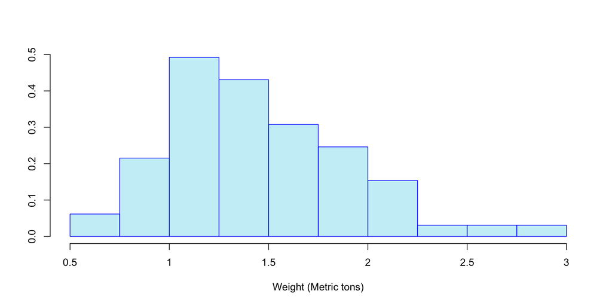

## Theory

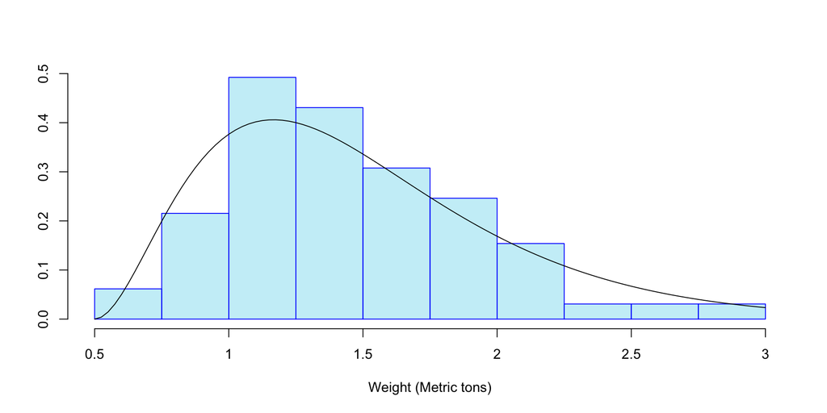

## Theory

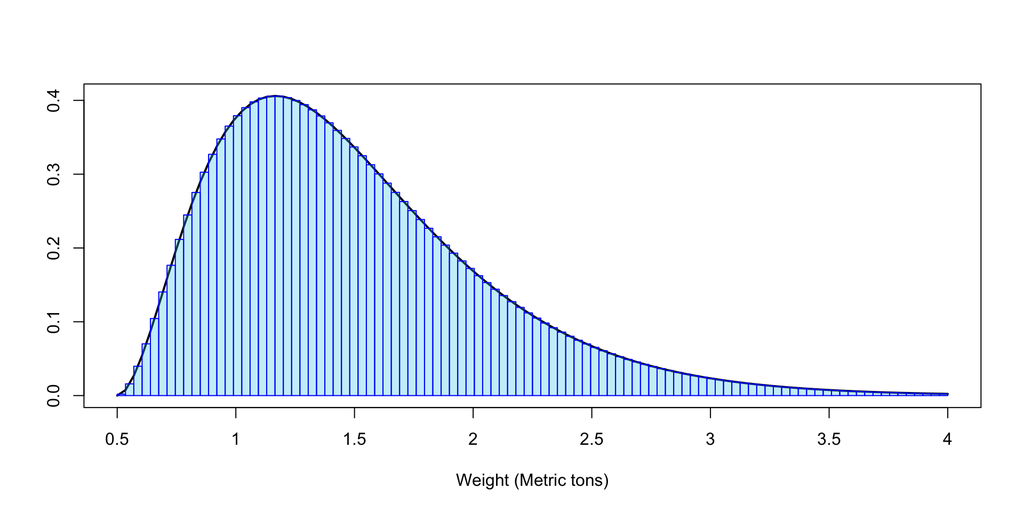

## Theory

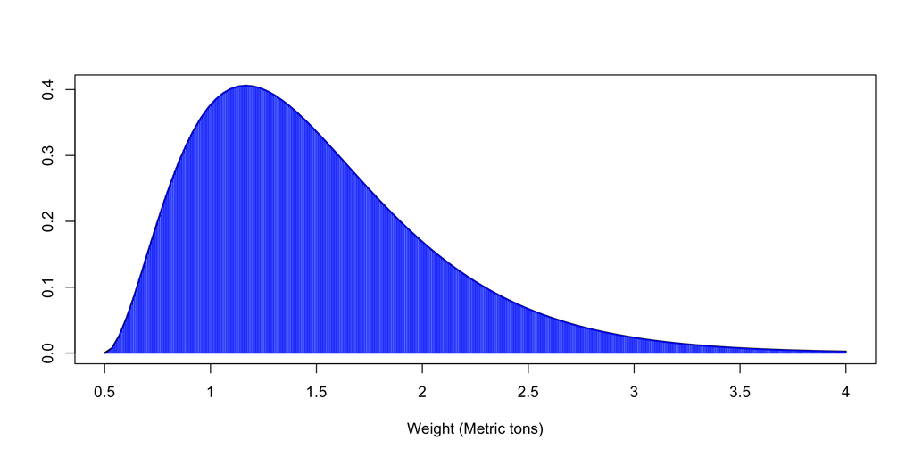

## Continuous Distributions

- Continuous random variable probabilities are discussed as **densities**
- **Probability density functions** must satisfy similar rules to PMFs
  - There’s an issue though

$$\int_{-\infty}^{\infty} f(x) dx = 1$$

$$0 \le \int_a^bf(x)dx \le 1$$

## Probability Density

**By definition** continuous probabilities are the *area under the curve* between two values within the distribution.

I have two rules for my class:

1. I won’t invite the formal practice of calculus into my classroom
2. I’ll burn at the stake before I use trigonometry

## Probability Density

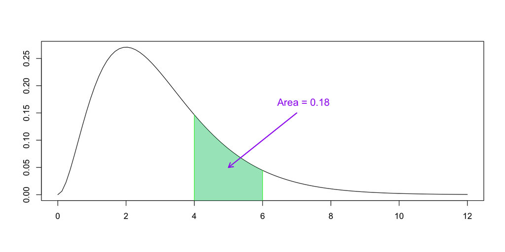

## Probability Density

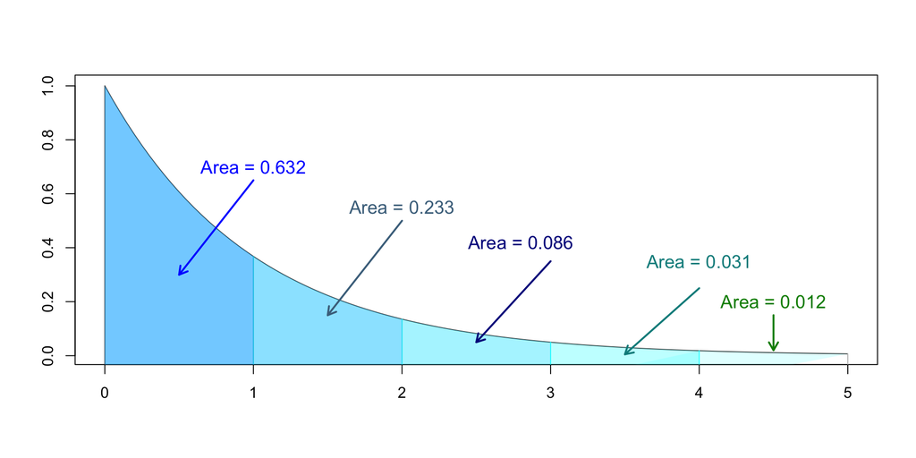

## Continuous Probabilities

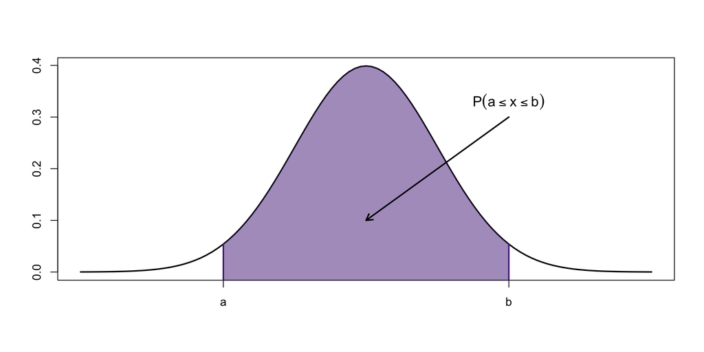

## Equality

[figure not shown]

## Uniform Distributions

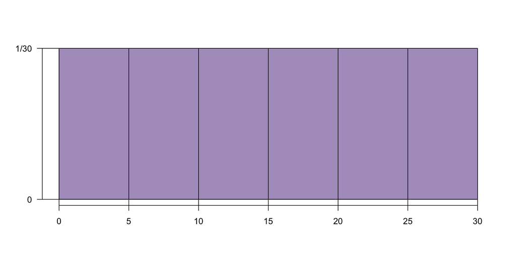

## Moments

$$\mathbb{E}X=\int_{-\infty}^\infty x \ f(x)dx$$

$$\mathbb{E}X^2=\int_{-\infty}^\infty x^2 \ f(x)dx$$

$$\mathbb{V}X=\mathbb{E}X^2-(\mathbb{E}X)^2$$

## Alternate Methods

> If you take STAT 341 (Biometrics II) you’ll have to be able to calculate these things. But that class doesn’t require advanced calculus.
- Sample interpolation
  - Guess exclusively from samples
- Numerical Quadrature
  - Draw boxes underneath the curve and calculate their areas
- Monte Carlo Simulation

## Distribution Theory

Another alternate option would be to calculate everything **once** and then *force* the data to look like our calculations

- This is the motivation behind the field of Distribution Theory
- There’s three important distributions we’ll talk about:
  - Symmetric curves
  - Coin flips
  - Uniform bars